# EDA

Ian Lo

11/29/2021

## Daily Trips Plotted with COVID Cases

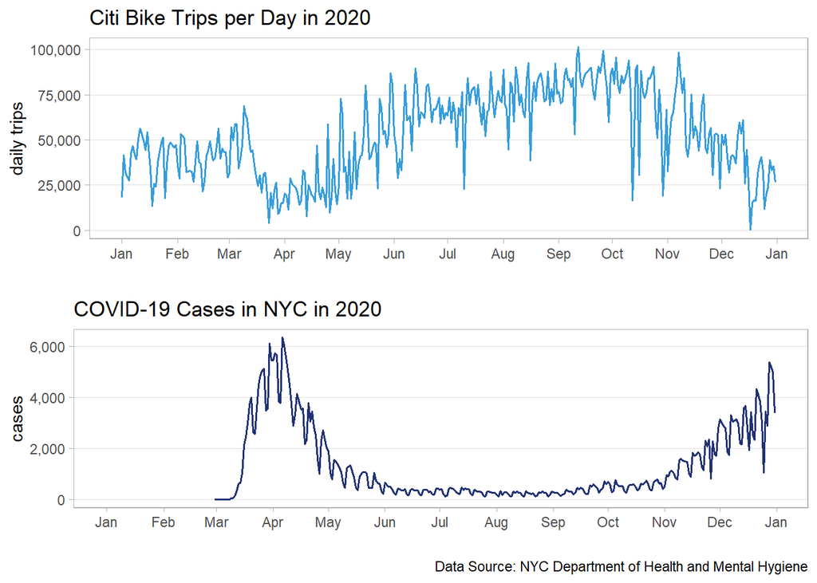

```r
# 2020 Citi Bike trips per day
trips_plot <- ggplot(data = bikedata_summarized, aes(trip_date, daily_trips)) +
  geom_line(color = "#379DDA", size = 0.7) +
  scale_x_date(date_breaks = "1 month", date_labels =  "%b") +
  scale_y_continuous(labels = scales::comma) +
  labs(title = "Citi Bike Trips per Day in 2020",
       x = "", y = "daily trips") +
  theme_light() +
  theme(panel.grid.minor = element_blank(),
        panel.grid.major.x = element_blank()
        )
# 2020 NYC COVID cases
# add blank rows since COVID data starts mid-March
coviddata_padded <- coviddata %>% pad('day', start_val = as.Date('2020-01-01'))

covid_plot <- ggplot(data = coviddata_padded %>% filter(date_of_interest < '2021-01-01'), aes(date_of_interest, CASE_COUNT)) +
  geom_line(color = "#213272", size = 0.7) +
  scale_x_date(date_breaks = "1 month", date_labels =  "%b") +
  scale_y_continuous(labels = scales::comma) +
  labs(title = "COVID-19 Cases in NYC in 2020",
        x = "",
        y = "cases",
        caption = "Data Source: NYC Department of Health and Mental Hygiene") +
  theme_light() +
  theme(panel.grid.minor = element_blank(),
        panel.grid.major.x = element_blank()
        )

grid.arrange(trips_plot, covid_plot, nrow = 2)
```

In the plot of daily bike trips, we can see the dip in March due to the start of the COVID-19 pandemic. As most of us know, New York City experienced a severe onset of the COVID-19 pandemic from March through April. From June through November, the number of cases seemed to be well-contained and stayed fairly constant, but We can also see cases beginning to surge again in November. Based on these two graphs alone, it would appear that the rise and fall in bike ridership could be correlated to the prevalence of COVID-19; however, we also know that cycling conditions should be heavily dependent on the weather (temperature, wind, rain, snow). The decrease in daily trips throughout the fall months is probably due to New York getting colder. We would also want to compare 2020 to 2019 since 2019 should represent ridership under normal, pre-COVID conditions.

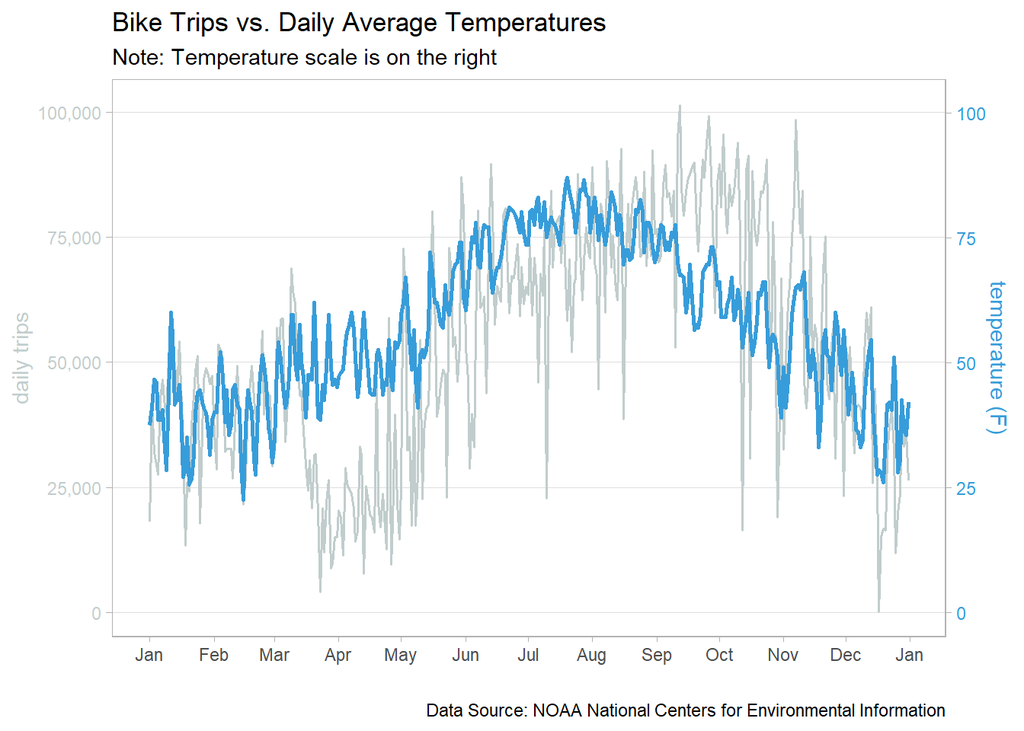

```r
weatherdata <- weatherdata %>% mutate(AVGTEMP = (TMAX+TMIN)/2)
weatherdata1 <- weatherdata %>% rename(trip_date = DATE)
bikeweatherdata <- left_join(bikedata_summarized, weatherdata1, by = "trip_date")

temperature_plot <- ggplot(data = bikeweatherdata, aes(x = trip_date)) +
  geom_line(aes(y = daily_trips), color = "azure3", size = 0.7) +
  geom_line(aes(y = AVGTEMP*1000), color = "#379DDA", size = 1) +
  scale_x_date(date_breaks = "1 month", date_labels = "%b") +
  scale_y_continuous(labels = scales::comma,
                     sec.axis = sec_axis(~./1000, name="temperature (F)")) +
  labs(title = "Bike Trips vs. Daily Average Temperatures",
       subtitle = "Note: Temperature scale is on the right",
       x = "", y = "daily trips",
       caption = "Data Source: NOAA National Centers for Environmental Information") +
  theme_light() +
  theme(panel.grid.minor = element_blank(),
        panel.grid.major.x = element_blank(),
        axis.title.y.left = element_text(colour="azure3"),
        axis.text.y.left = element_text(colour="azure3"),
        axis.title.y.right = element_text(colour="#379DDA"),
        axis.text.y.right = element_text(colour="#379DDA")
        )
temperature_plot
```

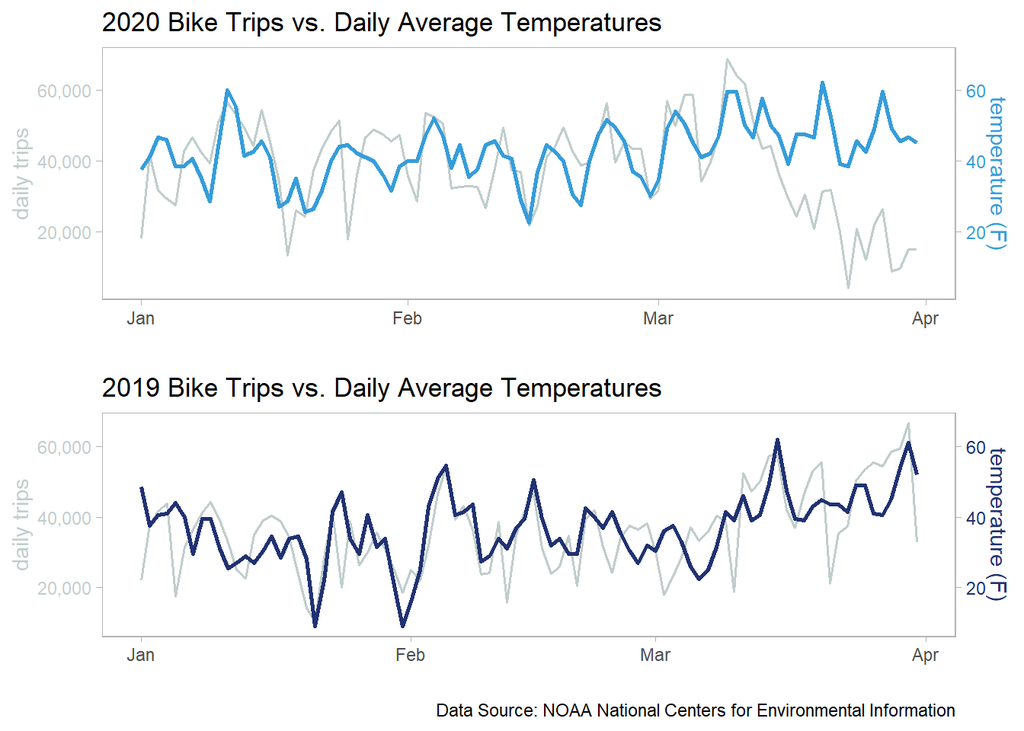

```r
weatherdata2019 <- weatherdata2019 %>% mutate(AVGTEMP = (TMAX+TMIN)/2)
weatherdata2019_1 <- weatherdata2019 %>% rename(trip_date = DATE)
bikeweatherdata2019 <- inner_join(bikedata_summarized_2019, weatherdata2019_1, by = "trip_date")

# 2020
temperature_plot_2020 <- ggplot(data = bikeweatherdata %>% filter(trip_date < as.Date('2020-04-01')), aes(x = trip_date)) +
  geom_line(aes(y = daily_trips), color = "azure3", size = 0.7) +
  geom_line(aes(y = AVGTEMP*1000), color = "#379DDA", size = 1) +
  # scale_x_date(date_breaks = "1 day", date_labels = "%b %d") +
  scale_y_continuous(labels = scales::comma,
                     sec.axis = sec_axis(~./1000, name="temperature (F)")) +
  labs(title = "2020 Bike Trips vs. Daily Average Temperatures",
       x = "", y = "daily trips") +
  theme_light() +
  theme(panel.grid.minor = element_blank(),
        panel.grid.major = element_blank(),
        axis.title.y.left = element_text(colour="azure3"),
        axis.text.y.left = element_text(colour="azure3"),
        axis.title.y.right = element_text(colour="#379DDA"),
        axis.text.y.right = element_text(colour="#379DDA")
        )

# 2019
temperature_plot_2019 <- ggplot(data = bikeweatherdata2019 %>% filter(trip_date < as.Date('2019-04-01')), aes(x = trip_date)) +
  geom_line(aes(y = daily_trips), color = "azure3", size = 0.7) +
  geom_line(aes(y = AVGTEMP*1000), color = "#213272", size = 1) +
  # scale_x_date(date_breaks = "1 day", date_labels = "%b %d") +
  scale_y_continuous(labels = scales::comma,
                     sec.axis = sec_axis(~./1000, name="temperature (F)")) +
  labs(title = "2019 Bike Trips vs. Daily Average Temperatures",
       x = "", y = "daily trips",
       caption = "Data Source: NOAA National Centers for Environmental Information") +
  theme_light() +
  theme(panel.grid.minor = element_blank(),
        panel.grid.major = element_blank(),
        axis.title.y.left = element_text(colour="azure3"),
        axis.text.y.left = element_text(colour="azure3"),
        axis.title.y.right = element_text(colour="#213272"),
        axis.text.y.right = element_text(colour="#213272")
        )


grid.arrange(temperature_plot_2020, temperature_plot_2019, nrow = 2)
```

Here we’re comparing 2020 to 2019 data for January through April and again, we see that in 2020 there’s a drop in bike trips in March that we otherwise wouldn’t have expected based on 2019, a non-COVID year.

### Daily Trips Plotted with Rainfall

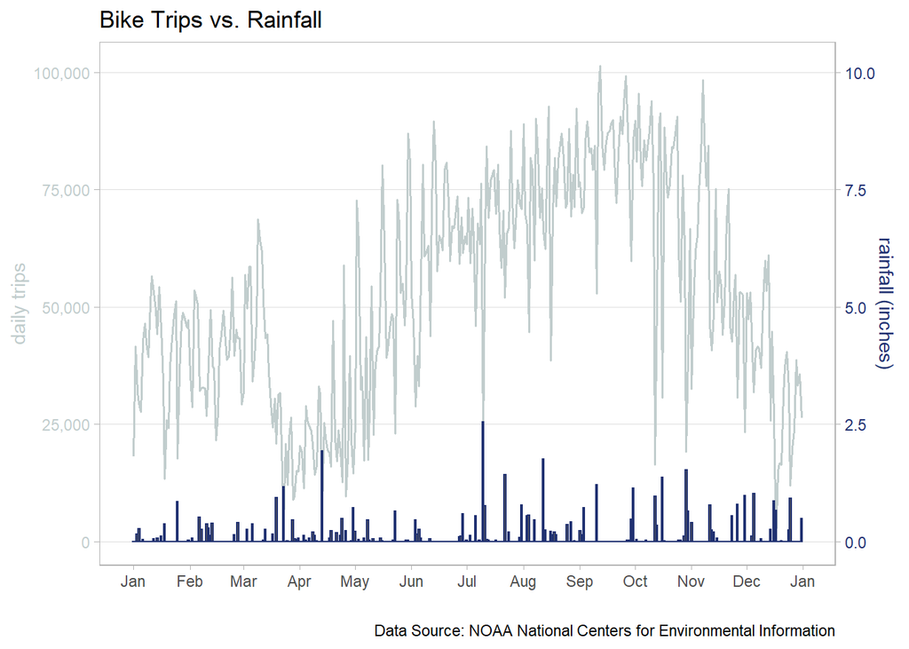

```r
rain_plot <- ggplot(data = bikeweatherdata, aes(x = trip_date)) +
  geom_line(aes(y = daily_trips), color = "azure3", size = 0.7) +
  geom_col(aes(y = PRCP*10000), color = "#213272") +
  scale_x_date(date_breaks = "1 month", date_labels = "%b") +
  scale_y_continuous(labels = scales::comma,
                     sec.axis = sec_axis(~./10000, name="rainfall (inches)")) +
  labs(title = "Bike Trips vs. Rainfall",
       x = "", y = "daily trips",
       caption = "Data Source: NOAA National Centers for Environmental Information") +
  theme_light() +
  theme(panel.grid.minor = element_blank(),
        panel.grid.major.x = element_blank(),
        axis.title.y.left = element_text(colour="azure3"),
        axis.text.y.left = element_text(colour="azure3"),
        axis.title.y.right = element_text(colour="#213272"),
        axis.text.y.right = element_text(colour="#213272")
        )
rain_plot
```

Another huge factor when it comes to biking is whether it’s raining. This is a plot of the daily rainfall (in inches) and we can see the peaks in rainfall matched to a sharp dip in bike trips for that day.